# Lab 4 Solutions

Tom Keefe

October 04, 2018

# Instructions

**Exercises:** 2,3 (Pg. 151); 2,4 (Pg. 156); 1,2 (Pgs. 160-161); 2 (Pg. 163); 2,3,4 (Pg. 168)

**Assigned:** Friday, September 28, 2018

**Due:** Friday, October 5, 2018 by 5:00 PM

**Submission:** Submit via an electronic document on Sakai. Must be submitted as a HTML file generated in RStudio. All assigned problems are chosen according to the textbook *R for Data Science*. You do not need R code to answer every question. If you answer without using R code, delete the code chunk. If the question requires R code, make sure you display R code. If the question requires a figure, make sure you display a figure. A lot of the questions can be answered in written response, but require R code and/or figures for understanding and explaining.

# Chapter 9 (Pg. 151)

## Exercise 2

First I extract the TB cases per country per year (part a), and the populations per year (part b), into separate dataframes.

```r
cases = table2 %>% filter(type=='cases')
populations = table2 %>% filter(type=='population')
```

Now to get the rates (part c), we pipe `cases` into `mutate`. The `mutate` function goes through `cases` row by row. For each row, `mutate` takes the value of `count`, which represents the number of cases of the disease, multiplies it by 10,000, and divides that by the value of `count` in the `populations` table *that has the same row index*.

```r
rates = cases %>% mutate(type = "rate", count=10000*count/populations$count)
```

To explain another way, we take the first row of `cases` (Afghanistan 1999), get the `count` (745), multiply by 10,000, get the first row of `population` (again Afghanistan 1999), get the `count` (19,987,071), and divide.

This only works because we know that the `cases` and `populations` have the same ordering.

Now we store it back in the appropriate place (part d). To match the format of table2, we should have “rate” in the `type` column, and the computed rate in the `count` column (although this is no longer really a count). We simply add these rows to `table2` using the `rbind` function, and then re-arrange to match the original format:

```r
table2 = rbind(table2, rates)
table2 = arrange(table2, country, year, type)
```

Now we do this all again with `table4a` and `table4b`:

When we compute the rates, we need to store them in a way that matches how the rest of the data is stored. That means the rates should go in a table called `table4c` that has columns `1999` and `2000`, and no other columns.

We use `mutate` in a similar manner as before: it goes through `table4a` row by row, and for each row it gets a value from a *corresponding* row in `table4b`.

```r
table4c = table4a %>% mutate(pop1999=table4b$`1999`,
                             pop2000=table4b$`2000`
                            )
table4c
```

```
## # A tibble: 3 x 5
##   country     `1999` `2000`    pop1999    pop2000
##   <chr>        <int>  <int>      <int>      <int>
## 1 Afghanistan    745   2666   19987071   20595360
## 2 Brazil       37737  80488  172006362  174504898
## 3 China       212258 213766 1272915272 1280428583
```

```r
table4c = table4c %>% mutate(`1999` = 10000*`1999`/pop1999,
                             `2000` = 10000*`2000`/pop2000) %>%
    select(country, `1999`, `2000`)
table4c
```

```
## # A tibble: 3 x 3
##   country     `1999` `2000`
##   <chr>        <dbl>  <dbl>
## 1 Afghanistan  0.373   1.29
## 2 Brazil       2.19    4.61
## 3 China        1.67    1.67
```

## Exercise 3

To recreate the plot using `table2`, we first need to filter on `type=='cases'`:

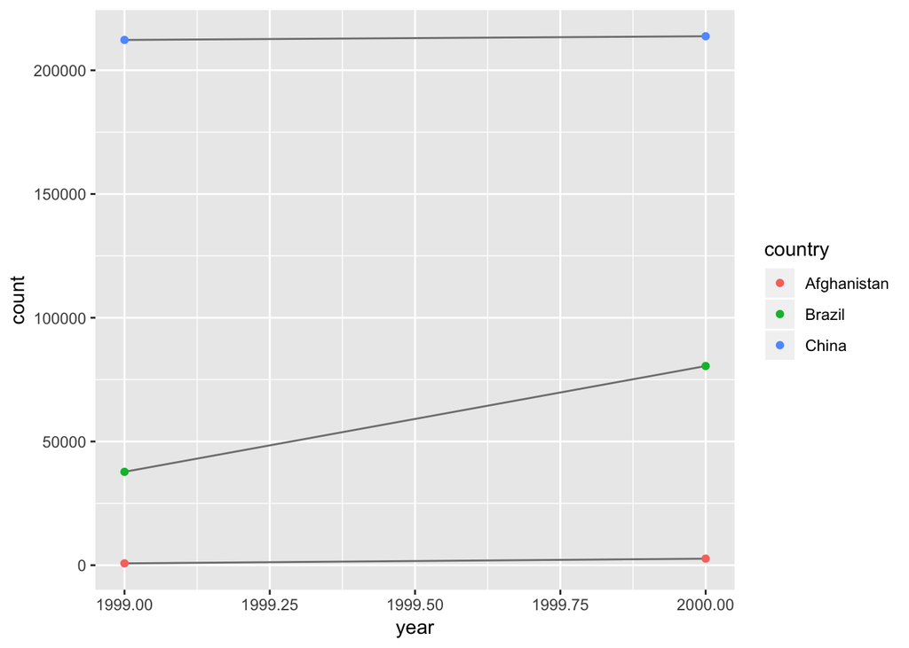

```r
table2 %>%
    filter(type=='cases') %>%
    ggplot(aes(x=year, y=count)) +
    geom_line(aes(group=country), color="grey50") +
    geom_point(aes(color=country))
```

# Chapter 9 (Pg. 156)

## Exercise 2

```r
table4a %>% gather(`1999`, `2000`, key="year", value="cases")
```

```
## # A tibble: 6 x 3
##   country     year   cases
##   <chr>       <chr>  <int>
## 1 Afghanistan 1999     745
## 2 Brazil      1999   37737
## 3 China       1999  212258
## 4 Afghanistan 2000    2666
## 5 Brazil      2000   80488
## 6 China       2000  213766
```

`1999` and `2000` need to be enclosed in backticks. (A good rule of thumb in data analytics is to not have your column names be numbers or start with numbers.)

## Exercise 4

```r
preg <- tribble(
    ~pregnant, ~male, ~female,
    "yes",     NA,    10,
    "no",      20,    12
)
```

This tibble represents numbers of males and females who are or are not pregnant. According to the principles of tidy data, each variable needs its own column, and each observation needs its own row. In this case, the column names `male` and `female` represent the *values* of a variable (call it `sex`). We need to `gather` these into a `sex` variable.

Another way to explain it: We’re measuring counts of people. These measurements are split over the columns `male` and `female`. In tidy data, one measurement should not split over columns. So, we need to use `gather` to make `male` and `female` values of a `sex` variable, and the corresponding counts all in one column, called `count`.

```r
preg %>% gather(male, female, key="sex", value="count")
```

```
## # A tibble: 4 x 3
##   pregnant sex    count
##   <chr>    <chr>  <dbl>
## 1 yes      male      NA
## 2 no       male      20
## 3 yes      female    10
## 4 no       female    12
```

# Chapter 9 (Pgs. 160-161)

## Exercise 1

We see from `?separate` what `extra` and `fill` are for. `extra` controls what happens when we separate an element into more pieces than we have columns to fit them into. `fill` controls what happens when there aren’t enough pieces to fill all our columns.

We try `extra='warn'` and `fill='warn'`:

```r
tibble(x = c("a,b,c", "d,e,f,g", "h,i,j")) %>%
    separate(x, c("one", "two", "three"), extra="warn")
```

```
## Warning: Expected 3 pieces. Additional pieces discarded in 1 rows [2].
```

```
## # A tibble: 3 x 3
##   one   two   three
##   <chr> <chr> <chr>
## 1 a     b     c
## 2 d     e     f
## 3 h     i     j
```

```r
tibble(x = c("a,b,c", "d,e", "f,g,i")) %>%
    separate(x, c("one", "two", "three"), fill="warn")
```

```
## Warning: Expected 3 pieces. Missing pieces filled with `NA` in 1 rows [2].
```

```
## # A tibble: 3 x 3
##   one   two   three
##   <chr> <chr> <chr>
## 1 a     b     c
## 2 d     e     <NA>
## 3 f     g     i
```

In the console we can see that warnings are generated (copied here):

```
Expected 3 pieces. Additional pieces discarded in 1 rows [2].
Expected 3 pieces. Missing pieces filled with `NA` in 1 rows [2].
```

Now we try `extra='drop'` and `fill='right'`:

```r
tibble(x = c("a,b,c", "d,e,f,g", "h,i,j")) %>%
    separate(x, c("one", "two", "three"), extra="drop")
```

```
## # A tibble: 3 x 3
##   one   two   three
##   <chr> <chr> <chr>
## 1 a     b     c
## 2 d     e     f
## 3 h     i     j
```

```r
tibble(x = c("a,b,c", "d,e", "f,g,i")) %>%
    separate(x, c("one", "two", "three"), fill="right")
```

```
## # A tibble: 3 x 3
##   one   two   three
##   <chr> <chr> <chr>
## 1 a     b     c
## 2 d     e     <NA>
## 3 f     g     i
```

We can see that in the first tibble, `g` is dropped from row 2 (there is no room for it); and in the second tibble, there is an NA in row 2, column three, because we fill in the right side with NAs.

Finally we try `extra='merge'` and `fill='left'`:

```r
tibble(x = c("a,b,c", "d,e,f,g", "h,i,j")) %>%
    separate(x, c("one", "two", "three"), extra="merge")
```

```
## # A tibble: 3 x 3
##   one   two   three
##   <chr> <chr> <chr>
## 1 a     b     c
## 2 d     e     f,g
## 3 h     i     j
```

```r
tibble(x = c("a,b,c", "d,e", "f,g,i")) %>%
    separate(x, c("one", "two", "three"), fill="left")
```

```
## # A tibble: 3 x 3
##   one   two   three
##   <chr> <chr> <chr>
## 1 a     b     c
## 2 <NA>  d     e
## 3 f     g     i
```

We see that in the first tibble, `f,g` are merged in row 2 column three. In the second tibble, there is an NA in row 2, column one, because we fill in missing values from the left with NAs.

## Exercise 2

The `remove` argument “removes the input column from the output data frame” (`?separate`). This arguement defaults to True. If we had a reason to keep the original column, we would set this to False. (We might do this if we united several columns to make a unique identifier; we would probably want to keep the original columns in that case.)

# Chapter 9 (Pg. 163)

## Exercise 2

Very occasionnaly, NA values may represent data carried forward, like writing ditto marks. `fill` replaces these NAs with the correct repeated value. `direction` is used to specify whether NAs should be filled using the preceding value or the next value. If an NA represents that the precededing value is repeated (this is the usual way) we use `direction="down"`. If the NA represents a repetition of the next non-NA value (this is rare), we use `direction="up"`.

# Chapter 9 (Pg. 168)

## Exercise 2

We need the `mutate` step to standardize the values of `key` so that they all start with `new_`. If we don’t do this, then when we separate `key` on underscores in the next step, the values that lack the underscore will not separate correctly into the desired columns.

## Exercise 3

Lets look at the pipeline before `iso2` and `iso3` are dropped:

```r
who %>%
  gather(key, value, new_sp_m014:newrel_f65, na.rm = TRUE) %>%
  mutate(key = stringr::str_replace(key, "newrel", "new_rel")) %>%
  separate(key, c("new", "var", "sexage")) %>%
  head()
```

```
## # A tibble: 6 x 8
##   country     iso2  iso3   year new   var   sexage value
##   <chr>       <chr> <chr> <int> <chr> <chr> <chr>  <int>
## 1 Afghanistan AF    AFG    1997 new   sp    m014       0
## 2 Afghanistan AF    AFG    1998 new   sp    m014      30
## 3 Afghanistan AF    AFG    1999 new   sp    m014       8
## 4 Afghanistan AF    AFG    2000 new   sp    m014      52
## 5 Afghanistan AF    AFG    2001 new   sp    m014     129
## 6 Afghanistan AF    AFG    2002 new   sp    m014      90
```

It looks like “Afghanistan”, “AF”, and “AFG” may all represent the same thing. One way to check this is to make a new dataset `who2`, and see if the number of unique countries equals the number of unique `country`, `iso2`, `iso3` tuples.

```r
who2 = who %>% unite(country_tuple, country, iso2, iso3, remove=FALSE)

head(who2)
```

```
## # A tibble: 6 x 61
##   country_tuple      country    iso2  iso3   year new_sp_m014 new_sp_m1524
##   <chr>              <chr>      <chr> <chr> <int>       <int>        <int>
## 1 Afghanistan_AF_AFG Afghanist… AF    AFG    1980          NA           NA
## 2 Afghanistan_AF_AFG Afghanist… AF    AFG    1981          NA           NA
## 3 Afghanistan_AF_AFG Afghanist… AF    AFG    1982          NA           NA
## 4 Afghanistan_AF_AFG Afghanist… AF    AFG    1983          NA           NA
## 5 Afghanistan_AF_AFG Afghanist… AF    AFG    1984          NA           NA
## 6 Afghanistan_AF_AFG Afghanist… AF    AFG    1985          NA           NA
## # ... with 54 more variables: new_sp_m2534 <int>, new_sp_m3544 <int>,
## #   new_sp_m4554 <int>, new_sp_m5564 <int>, new_sp_m65 <int>,
## #   new_sp_f014 <int>, new_sp_f1524 <int>, new_sp_f2534 <int>,
## #   new_sp_f3544 <int>, new_sp_f4554 <int>, new_sp_f5564 <int>,
## #   new_sp_f65 <int>, new_sn_m014 <int>, new_sn_m1524 <int>,
## #   new_sn_m2534 <int>, new_sn_m3544 <int>, new_sn_m4554 <int>,
## #   new_sn_m5564 <int>, new_sn_m65 <int>, new_sn_f014 <int>,
## #   new_sn_f1524 <int>, new_sn_f2534 <int>, new_sn_f3544 <int>,
## #   new_sn_f4554 <int>, new_sn_f5564 <int>, new_sn_f65 <int>,
## #   new_ep_m014 <int>, new_ep_m1524 <int>, new_ep_m2534 <int>,
## #   new_ep_m3544 <int>, new_ep_m4554 <int>, new_ep_m5564 <int>,
## #   new_ep_m65 <int>, new_ep_f014 <int>, new_ep_f1524 <int>,
## #   new_ep_f2534 <int>, new_ep_f3544 <int>, new_ep_f4554 <int>,
## #   new_ep_f5564 <int>, new_ep_f65 <int>, newrel_m014 <int>,
## #   newrel_m1524 <int>, newrel_m2534 <int>, newrel_m3544 <int>,
## #   newrel_m4554 <int>, newrel_m5564 <int>, newrel_m65 <int>,
## #   newrel_f014 <int>, newrel_f1524 <int>, newrel_f2534 <int>,
## #   newrel_f3544 <int>, newrel_f4554 <int>, newrel_f5564 <int>,
## #   newrel_f65 <int>
```

Now we get the unique counts:

```r
length(unique(who2$country))
```

```
## [1] 219
```

```r
length(unique(who2$country_tuple))
```

```
## [1] 219
```

These are both 219, so we conclude `iso2` and `iso3` are redundant.

## Exercise 4

First I use Wickham’s code to tidy the `who` data into a new tibble:

```r
tidy_who = who %>%
  gather(key, value, new_sp_m014:newrel_f65, na.rm = TRUE) %>%
  mutate(key = stringr::str_replace(key, "newrel", "new_rel")) %>%
  separate(key, c("new", "var", "sexage")) %>%
  select(-new, -iso2, -iso3) %>%
  separate(sexage, c("sex", "age"), sep = 1)
```

Lets take a look at the top of the dataset:

```r
head(tidy_who)
```

```
## # A tibble: 6 x 6
##   country      year var   sex   age   value
##   <chr>       <int> <chr> <chr> <chr> <int>
## 1 Afghanistan  1997 sp    m     014       0
## 2 Afghanistan  1998 sp    m     014      30
## 3 Afghanistan  1999 sp    m     014       8
## 4 Afghanistan  2000 sp    m     014      52
## 5 Afghanistan  2001 sp    m     014     129
## 6 Afghanistan  2002 sp    m     014      90
```

So, we will use a group_by and summarize to count the number of cases for each combination of country, year, and sex. So, if our group is (Afghanistan, 1997, males), we will sum up the TB cases (`value`) over each `age` and `var`.

```r
tb_cases = tidy_who %>%
    group_by(country, year, sex) %>%
    summarize(cases = sum(value))
head(tb_cases)
```

```
## # A tibble: 6 x 4
## # Groups:   country, year [3]
##   country      year sex   cases
##   <chr>       <int> <chr> <int>
## 1 Afghanistan  1997 f       102
## 2 Afghanistan  1997 m        26
## 3 Afghanistan  1998 f      1207
## 4 Afghanistan  1998 m       571
## 5 Afghanistan  1999 f       517
## 6 Afghanistan  1999 m       228
```

And now we make a visualization. There are too many countries to deal with, so I will look at how cases of TB have been distributed by sex each year (1995-2012, because it looks like data collection was best in those years)

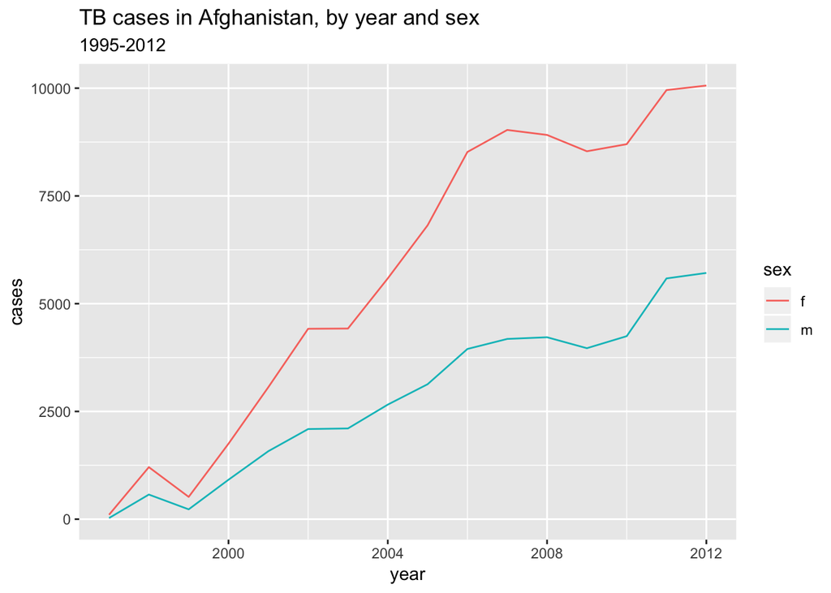

```r
tb_cases %>%
    filter(country=="Afghanistan", year %in% 1995:2012) %>%
    ggplot() +
    geom_line(aes(x=year, y=cases, color=sex)) +
    ggtitle("TB cases in Afghanistan, by year and sex", "1995-2012")
```